# Project1

Anna Toidze

10/24/2021

# Analysis of olympic games

In this project it is assumed that the zipped raw data is located in a folder called *data_folder*, located in the directory above the current one. First we unzip our data saved as *athlete_events.zip*:

```bash
pwd
rm ../data_folder/*.csv
unzip ../data_folder/athlete_events.zip -d ../data_folder/
```

Let’s see how our data looks like:

```bash
ls ../data_folder/
```

```
## athlete_events00.csv
## athlete_events01.csv
## athlete_events02.csv
## athlete_events03.csv
## athlete_events04.csv
## athlete_events05.csv
## athlete_events06.csv
## athlete_events07.csv
## athlete_events08.csv
## athlete_events09.csv
## athlete_events10.csv
## athlete_events11.csv
## athlete_events.zip
## features_description.txt
```

```r
#if (!require(x, character.only = TRUE)) {
#      install.packages(x, dependencies = TRUE)
#      library(x, character.only = TRUE)
#    }
library(dplyr)
library(ggplot2)
library(ggExtra)
library(cowplot)
library(car)
library(broomExtra)
library(purrr)
```

Uniting all data in one datafram *df_ol*:

```r
uniting_data <- function(path, extension = "csv"){
  pattern <- paste0("*.", extension)
  myfiles <-  paste0(path, list.files(path, pattern=pattern, all.files=FALSE,
           full.names=FALSE))
  myfiles %>% lapply(read.csv) %>% bind_rows()
}
path <- "../data_folder/"

df_ol <- uniting_data(path, "csv")
```

**2.** Checking whether our data is actually correct:

```r
str(df_ol)
unique(df_ol$Sex)
unique(df_ol$Season)
unique(df_ol$Medal)
```

[output not shown]

It’s obvious, that instead of *NA* empty string *““* has sometimes been used to showcase the lacking data. Let’s reload our data with correct parameters:

```r
uniting_data <- function(path, extension = "csv", na = "NA"){
  pattern <- paste0("*.", extension)
  myfiles <-  paste0(path, list.files(path, pattern=pattern, all.files=FALSE,
           full.names=FALSE))
  myfiles %>% lapply(read.csv, na.string = na) %>% bind_rows()
}

df_ol <- uniting_data("../data_folder/", "csv", na = c("", "NA"))
```

Let’s factor our data, “G” has been changed to “M” based on the names of the participants and the events they participated in:

```r
unique(df_ol$Sex)
```

```
## [1] "M" "F" "G" NA
```

```r
df_ol <- df_ol %>% mutate(Sex=replace(Sex, Sex == "G", "M")) #df_ol[which(df_ol$Sex == "G"),] <- "M"

str(df_ol)
```

```
## 'data.frame':    271115 obs. of  15 variables:
##  $ ID    : int  1 2 3 4 5 5 5 5 5 5 ...
##  $ Name  : chr  "A Dijiang" "A Lamusi" "Gunnar Nielsen Aaby" "Edgar Lindenau Aabye" ...
##  $ Sex   : chr  "M" "M" "M" "M" ...
##  $ Age   : int  24 23 24 34 21 21 25 25 27 27 ...
##  $ Height: int  180 170 NA NA 185 185 185 185 185 185 ...
##  $ Weight: num  80 60 NA NA 82 82 82 82 82 82 ...
##  $ Team  : chr  "China" "China" "Denmark" "Denmark/Sweden" ...
##  $ NOC   : chr  "CHN" "CHN" "DEN" "DEN" ...
##  $ Games : chr  "1992 Summer" "2012 Summer" "1920 Summer" "1900 Summer" ...
##  $ Year  : int  1992 2012 1920 1900 1988 1988 1992 1992 1994 1994 ...
##  $ Season: chr  "Summer" "Summer" "Summer" "Summer" ...
##  $ City  : chr  "Barcelona" "London" "Antwerpen" "Paris" ...
##  $ Sport : chr  "Basketball" "Judo" "Football" "Tug-Of-War" ...
##  $ Event : chr  "Basketball Men's Basketball" "Judo Men's Extra-Lightweight" "Football Men's Football" "Tug-Of-War Men's Tug-Of-War" ...
##  $ Medal : chr  NA NA NA "Gold" ...
```

```r
df_ol$Sex <- factor(df_ol$Sex)
df_ol$Season <- factor(df_ol$Season)
df_ol$Medal <- factor(df_ol$Medal)
```

Let’s check some other parameters starting with Sport column. There seems to be an typo with football - “Footba” instead of “Football”.

```r
unique(df_ol$Sport)
```

```
##  [1] "Basketball"                "Judo"
##  [3] "Football"                  "Tug-Of-War"
##  [5] "Speed Skating"             "Cross Country Skiing"
##  [7] "Athletics"                 "Ice Hockey"
##  [9] "Swimming"                  "Badminton"
## [11] "Sailing"                   "Biathlon"
## [13] "Gymnastics"                "Art Competitions"
## [15] "Alpine Skiing"             "Handball"
## [17] "Weightlifting"             "Wrestling"
## [19] "Luge"                      "Water Polo"
## [21] "Hockey"                    "Rowing"
## [23] "Bobsleigh"                 "Fencing"
## [25] "Equestrianism"             "Shooting"
## [27] "Boxing"                    "Taekwondo"
## [29] "Cycling"                   "Diving"
```

[output cut: 19 more lines]

```r
df_ol <- df_ol %>% mutate(Sport=replace(Sport, Sport == "Footba", "Football"))
unique(df_ol$Sport)
```

```
##  [1] "Basketball"                "Judo"
##  [3] "Football"                  "Tug-Of-War"
##  [5] "Speed Skating"             "Cross Country Skiing"
##  [7] "Athletics"                 "Ice Hockey"
##  [9] "Swimming"                  "Badminton"
## [11] "Sailing"                   "Biathlon"
## [13] "Gymnastics"                "Art Competitions"
## [15] "Alpine Skiing"             "Handball"
## [17] "Weightlifting"             "Wrestling"
## [19] "Luge"                      "Water Polo"
## [21] "Hockey"                    "Rowing"
## [23] "Bobsleigh"                 "Fencing"
## [25] "Equestrianism"             "Shooting"
## [27] "Boxing"                    "Taekwondo"
## [29] "Cycling"                   "Diving"
```

[output cut: 19 more lines]

Let’s check our weight, age and height distributions.

```r
max(df_ol$Weight, na.rm = T)
```

```
## [1] 214
```

```r
min(df_ol$Weight, na.rm = T)
```

```
## [1] 7
```

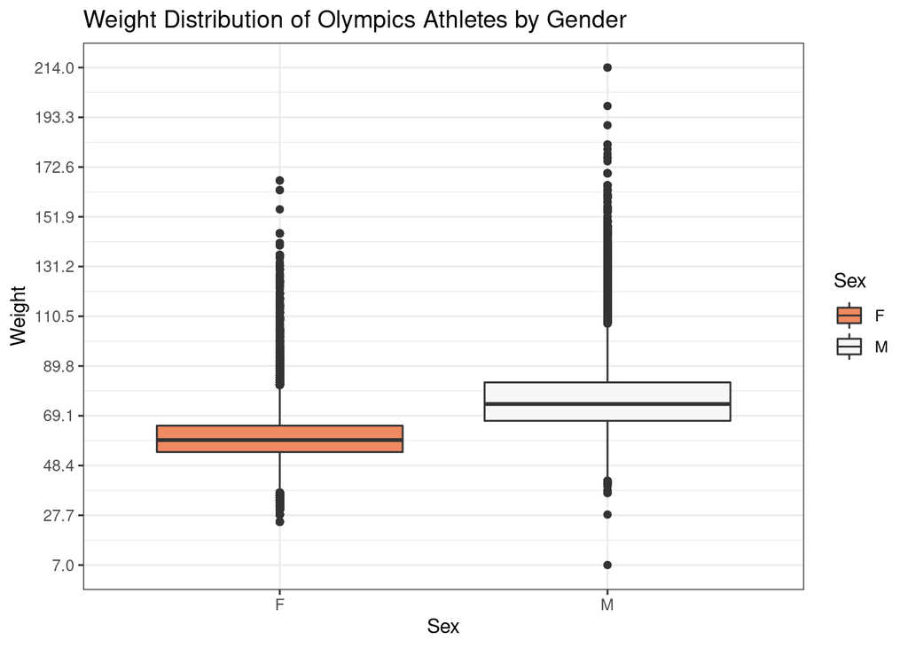

```r
ggplot(subset(df_ol, complete.cases(Sex)), aes(x=Sex, y = Weight, fill = Sex))+
  geom_boxplot()+
  scale_fill_brewer(palette="RdBu") +
  scale_y_continuous(limits = c(min(df_ol$Weight, na.rm = T)
, max(df_ol$Weight, na.rm = T)), breaks = seq(min(df_ol$Weight, na.rm = T)
, max(df_ol$Weight, na.rm = T)
, (max(df_ol$Weight, na.rm = T)-min(df_ol$Weight, na.rm = T))/10
)) +

   labs(title= "Weight Distribution of Olympics Athletes by Gender")+
  theme_bw()
```

We have a weird outlier with the weight of less than 25. We have Helmut Lehmann, who doesn’t really contribute anything except for his age and height - no other parameters are known. Let’s just filter him off.

```r
df_ol[which(df_ol$Weight < 25),]
```

```
##           ID           Name Sex Age Height Weight Team  NOC Games Year Season
## 135886 68370 Helmut Lehmann   M  25    178      7 <NA> <NA>  <NA>   NA   <NA>
##        City Sport Event Medal
## 135886 <NA>  <NA>  <NA>  <NA>
```

```r
df_ol <- df_ol[-c(which(df_ol$Weight < 25)),]
```

Let’s do the same with age and height. We have a very tall female, with height of 340 which is impossible, and a male of age 240. Let’s check whether that woman might have participated in other events as well and substitute her height accordingly. Same goes for the age.

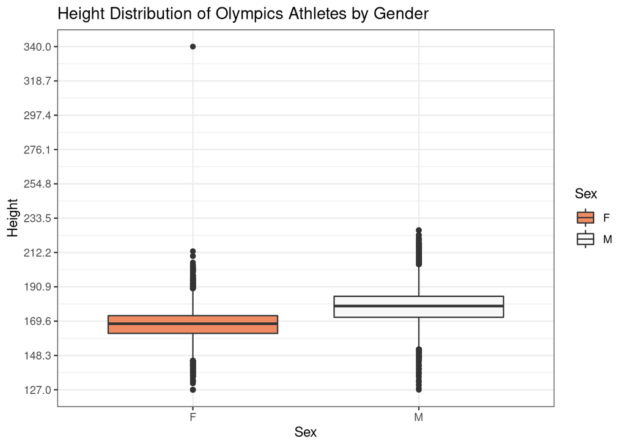

```r
ggplot(subset(df_ol, complete.cases(Sex)), aes(x=Sex, y = Height, fill = Sex))+
  geom_boxplot()+
  scale_fill_brewer(palette="RdBu") +
  scale_y_continuous(limits = c(min(df_ol$Height, na.rm = T)
, max(df_ol$Height, na.rm = T)), breaks = seq(min(df_ol$Height, na.rm = T)
, max(df_ol$Height, na.rm = T)
, (max(df_ol$Height, na.rm = T)-min(df_ol$Height, na.rm = T))/10
)) +

   labs(title= "Height Distribution of Olympics Athletes by Gender")+
  theme_bw()
```

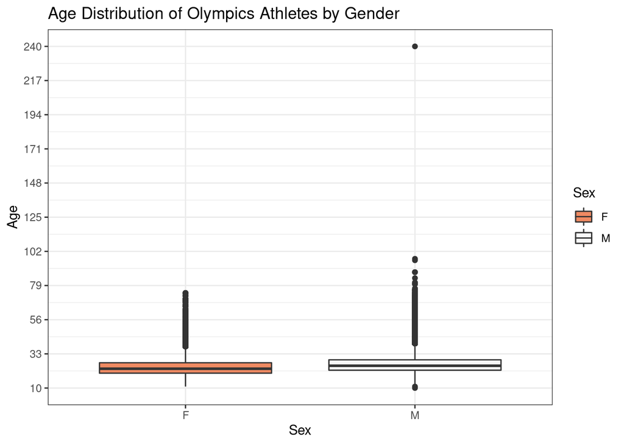

```r
ggplot(subset(df_ol, complete.cases(Sex)), aes(x=Sex, y = Age, fill = Sex))+
  geom_boxplot()+
  scale_fill_brewer(palette="RdBu") +
  scale_y_continuous(limits = c(min(df_ol$Age, na.rm = T)
, max(df_ol$Age, na.rm = T)), breaks = seq(min(df_ol$Age, na.rm = T)
, max(df_ol$Age, na.rm = T)
, (max(df_ol$Age, na.rm = T)-min(df_ol$Age, na.rm = T))/10
)) +

   labs(title= "Age Distribution of Olympics Athletes by Gender")+
  theme_bw()
```

```r
#Who is 340 cm tall?
df_ol[which(df_ol$Height == 340),]
```

```
##          ID                            Name Sex Age Height Weight     Team NOC
## 45651 23549 Kirsty Leigh Coventry (-Seward)   F  28    340     64 Zimbabwe ZIM
##             Games Year Season   City    Sport
## 45651 2012 Summer 2012 Summer London Swimming
##                                               Event Medal
## 45651 Swimming Women's 200 metres Individual Medley  <NA>
```

```r
#Let's check her height:
df_ol[which(df_ol$Name == "Kirsty Leigh Coventry (-Seward)"),]
```

```
##          ID                            Name Sex Age Height Weight     Team NOC
## 45638 23549 Kirsty Leigh Coventry (-Seward)   F  16    176     64 Zimbabwe ZIM
## 45639 23549 Kirsty Leigh Coventry (-Seward)   F  16    176     64 Zimbabwe ZIM
## 45640 23549 Kirsty Leigh Coventry (-Seward)   F  16    176     64 Zimbabwe ZIM
## 45641 23549 Kirsty Leigh Coventry (-Seward)   F  16    176     64 Zimbabwe ZIM
## 45642 23549 Kirsty Leigh Coventry (-Seward)   F  20    176     64 Zimbabwe ZIM
## 45643 23549 Kirsty Leigh Coventry (-Seward)   F  20    176     64 Zimbabwe ZIM
## 45644 23549 Kirsty Leigh Coventry (-Seward)   F  20    176     64 Zimbabwe ZIM
## 45645 23549 Kirsty Leigh Coventry (-Seward)   F  24    176     64 Zimbabwe ZIM
## 45646 23549 Kirsty Leigh Coventry (-Seward)   F  24    176     64 Zimbabwe ZIM
## 45647 23549 Kirsty Leigh Coventry (-Seward)   F  24    176     64 Zimbabwe ZIM
## 45648 23549 Kirsty Leigh Coventry (-Seward)   F  24    176     64 Zimbabwe ZIM
## 45649 23549 Kirsty Leigh Coventry (-Seward)   F  28    176     64 Zimbabwe ZIM
## 45650 23549 Kirsty Leigh Coventry (-Seward)   F  28    176     64 Zimbabwe ZIM
## 45651 23549 Kirsty Leigh Coventry (-Seward)   F  28    340     64 Zimbabwe ZIM
```

[output cut: 36 more lines]

```r
#It seems to be 176 cm, let's correct the false data:
df_ol <- df_ol %>% mutate(Height=replace(Height, Height == 340, 176))
#Now height distribution looks good

#Who's 240 years old?
df_ol[which(df_ol$Age == 240), 10]
```

```
## [1] 1912
```

```r
#Let's check whether he participated in other events as well:
df_ol %>% filter(Name == "Flicien Jules mile Courbet", Year == df_ol[which(df_ol$Age == 240), 10])
```

```
##      ID                       Name Sex Age Height Weight    Team NOC
## 1 23459 Flicien Jules mile Courbet   M  24     NA     NA Belgium BEL
## 2 23459 Flicien Jules mile Courbet   M 240     NA     NA Belgium BEL
## 3 23459 Flicien Jules mile Courbet   M  24     NA     NA Belgium BEL
##         Games Year Season      City      Sport
## 1 1912 Summer 1912 Summer Stockholm Water Polo
## 2 1912 Summer 1912 Summer Stockholm   Swimming
## 3 1912 Summer 1912 Summer Stockholm   Swimming
##                                    Event  Medal
## 1            Water Polo Men's Water Polo Bronze
## 2 Swimming Men's 200 metres Breaststroke   <NA>
## 3 Swimming Men's 400 metres Breaststroke   <NA>
```

```r
#We see he's 24 that year:
df_ol <- df_ol %>%  mutate(Age=replace(Age, Age == 240, 24))
#Now age distribution is fixed
```

**3.** The age of two youngest athletes of each sex on Olympics in year 1992:

```r
df_ol %>% filter(Year == 1992) %>% arrange(Age) %>% group_by(Sex) %>% slice(c(1)) %>% select(Age)
```

```
## # A tibble: 2 × 2
## # Groups:   Sex [2]
##   Sex     Age
##   <fct> <dbl>
## 1 F        12
## 2 M        11
```

**4.** Calculate mean and standard deviation for **height**, each sex:

```r
aggregate(df_ol$Height, by = list(df_ol$Sex) , FUN = function(x) cbind(mean(x, na.rm = T), sd(x, na.rm = T)))
```

```
##   Group.1        x.1        x.2
## 1       F 167.839728   8.778463
## 2       M 178.858620   9.360377
```

```r
df_ol[complete.cases(df_ol[,3]),] %>%  group_by(Sex) %>%
  summarize(
    mean = mean(Height, na.rm = TRUE),  sd = sd(Height, na.rm = T)
  )
```

```
## # A tibble: 2 × 3
##   Sex    mean    sd
##   <fct> <dbl> <dbl>
## 1 F      168.  8.78
## 2 M      179.  9.36
```

```r
df_ol %>% filter(is.na(Sex) == F) %>% group_by(Sex) %>%
  summarize(
    mean = mean(Height, na.rm = TRUE),  sd = sd(Height, na.rm = T)
  )
```

```
## # A tibble: 2 × 3
##   Sex    mean    sd
##   <fct> <dbl> <dbl>
## 1 F      168.  8.78
## 2 M      179.  9.36
```

```r
df_ol %>% filter(Sex %in% "F", Year %in% 2000) %>%
  summarize(
    mean = round(mean(Height, na.rm = TRUE), 1),  sd = round(sd(Height, na.rm = T), 1)
  )
```

```
##   mean  sd
## 1  169 9.5
```

**6.** In which category of sport did the heaviest athlete of 2006 Olympics participate?

```r
df_ol %>% filter(Year %in% 2006) %>%
  arrange(-Weight) %>%
  slice(1) %>%
  select(Sport)
```

```
##      Sport
## 1 Skeleton
```

**7.** How many gold medals obtained by females from 1980 till 2010 (both inclusive)?

```r
df_ol %>% filter(Sex %in% "F", Year %in% (1980:2010), Medal %in% "Gold") %>% summarize( n = n())
```

```
##      n
## 1 2249
```

**8.** How many times did John Aalberg participate in Olympic games over the years in total?

```r
df_ol %>% filter(Name == "John Aalberg") %>%
  summarize(n = length(unique(Year)))
```

```
##   n
## 1 2
```

He participated twice in Olympic games.

```r
df_ol %>% filter(Year %in% 2002) %>%
  mutate(Agegroup = cut(Age, breaks = c(15, 25, 35, 45, 56), right = F)) %>%
  group_by(Agegroup) %>%
  summarize(n = n()) %>%
  slice(which.max(n), which.min(n))
```

```
## # A tibble: 2 × 2
##   Agegroup     n
##   <fct>    <int>
## 1 [25,35)   2230
## 2 [45,56)      8
```

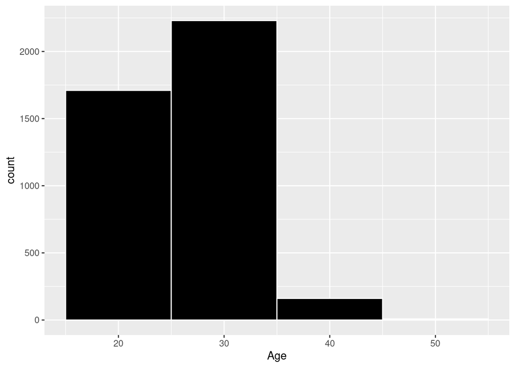

```r
# df_ol_agegr[c(which.max(df_ol_agegr$n), which.min(df_ol_agegr$n)),]

df_ol_2002 <- df_ol[df_ol$Year %in% 2002, ]
ggplot(df_ol_2002, aes(Age)) +
  geom_histogram(boundary = 15, binwidth = 10, bins = 5, color = "white", fill = "black", right = F)
```

**10.** How did the number of different categories of sports change from 1994 to 2002 Olympics?

```r
df_ol_num_sports_02_94 <- df_ol %>% filter(Year %in% c(1994, 2002)) %>%
  group_by(Year) %>%
  summarize(n = length(unique(Sport)))


#Increase by:
df_ol_num_sports_02_94$n[2] - df_ol_num_sports_02_94$n[1]
```

```
## [1] 3
```

**11.** What are the top 3 countries for each Olympics season and medal?

```r
df_ol %>% filter(is.na(Medal) == F) %>%
  group_by(Season, Medal, NOC) %>%
  summarize(n = n()) %>%
  summarize("Num. of Medals" = max(n), Country = paste(NOC[which(n == max(n))], collapse = ", "))
```

```
## # A tibble: 6 × 4
## # Groups:   Season [2]
##   Season Medal  `Num. of Medals` Country
##   <fct>  <fct>             <int> <chr>
## 1 Summer Bronze             1197 USA
## 2 Summer Gold               2472 USA
## 3 Summer Silver             1333 USA
## 4 Winter Bronze              215 FIN
## 5 Winter Gold                305 CAN
## 6 Winter Silver              308 USA
```

```r
df_ol %>% filter(is.na(Medal) == F) %>%
  group_by(Season, Medal, NOC) %>%
  summarize(n = n()) %>%
  arrange(-n) %>%
  slice(1:3) %>%
 summarise_all(~paste(., collapse = '; '))
```

```
## # A tibble: 6 × 4
## # Groups:   Season [2]
##   Season Medal  NOC           n
##   <fct>  <fct>  <chr>         <chr>
## 1 Summer Bronze USA; GER; GBR 1197; 649; 620
## 2 Summer Gold   USA; URS; GBR 2472; 832; 636
## 3 Summer Silver USA; GBR; URS 1333; 729; 635
## 4 Winter Bronze FIN; SWE; USA 215; 177; 161
## 5 Winter Gold   CAN; URS; USA 305; 250; 166
## 6 Winter Silver USA; CAN; NOR 308; 199; 165
```

**12.** Put standardized height values into a new column *Height_z_scores*:

```r
df_ol_z <- df_ol %>%
  mutate(Height_z_scores = (Height - mean(Height, na.rm =T))/sd(Height, na.rm = T))

head(scale(df_ol$Height))
```

```
##            [,1]
## [1,]  0.4431254
## [2,] -0.5075774
## [3,]         NA
## [4,]         NA
## [5,]  0.9184768
## [6,]  0.9184768
```

```r
df_ol_scale <- df_ol %>% mutate(Height_scaled = scale(Height))
```

**13.** Put standardized height values into a new column *Height_min_max_scores* (min-max normalization, every value in [0,1]):

```r
df_ol_z_minmax <- df_ol_z %>%
  mutate(Height_min_max_scaled = (Height - min(Height, na.rm =T))/(max(Height, na.rm = T)-min(Height, na.rm =T)))
```

**14.** Height, weight and age of male and female athletes, that participated in winter Olympics. As these variables are continuous, we could theoriticaly compare them by t-test. For this purpose, we first have to test for normal distribution.

```r
#General statistics:
df_ol %>% filter(Season %in% "Winter") %>%
  group_by(Sex) %>%
  summarize(across(.cols = c(Height, Weight, Age), list(mean = ~ round(mean(x = ., na.rm = T), 2), sd = ~ round(sd(x = ., na.rm = T), 2))))
```

```
## # A tibble: 2 × 7
##   Sex   Height_mean Height_sd Weight_mean Weight_sd Age_mean Age_sd
##   <fct>       <dbl>     <dbl>       <dbl>     <dbl>    <dbl>  <dbl>
## 1 F            167.      6.03        59.8      7.06     24.0   4.69
## 2 M            179.      6.59        76.4     10.3      25.5   4.75
```

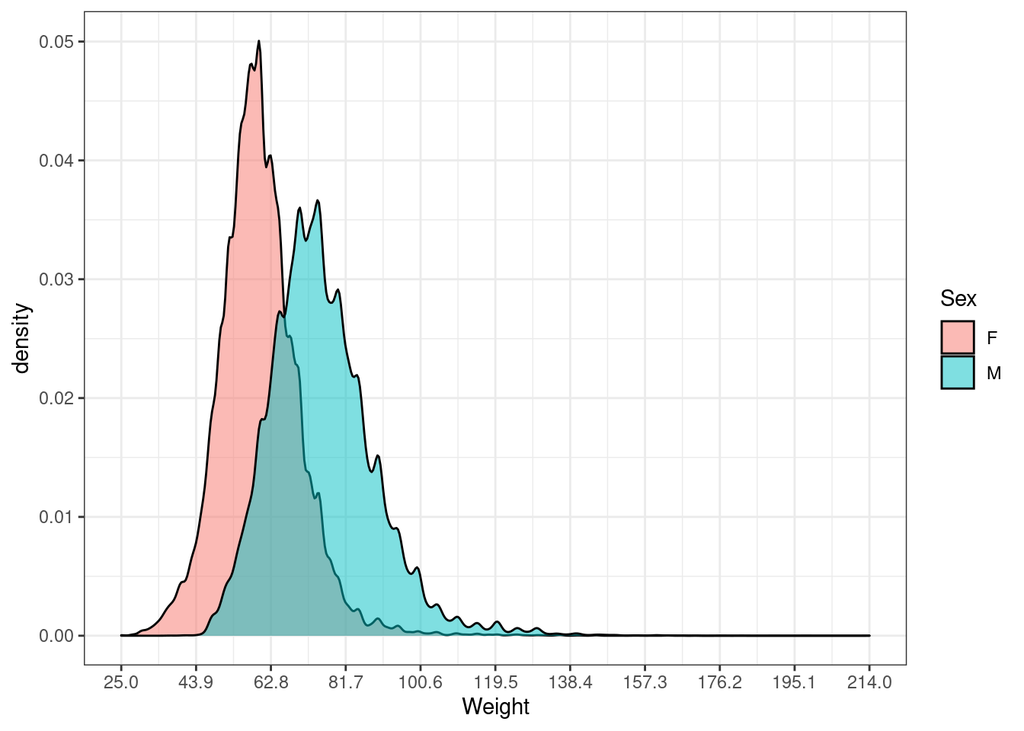

```r
#Testing for normal distribution
ggplot(subset(df_ol, complete.cases(Sex)), aes(Weight, fill = Sex))+
  geom_density(alpha = 0.5)+
  scale_x_continuous(name = "Weight",
                     limits = c(min(df_ol$Weight, na.rm = T), max(df_ol$Weight, na.rm = T)),
                     breaks = seq(min(df_ol$Weight, na.rm = T), max(df_ol$Weight, na.rm = T),
                                  (max(df_ol$Weight, na.rm=T)-min(df_ol$Weight, na.rm = T))/10)) +
  scale_fill_discrete(name = "Sex")+
  theme_bw()
```

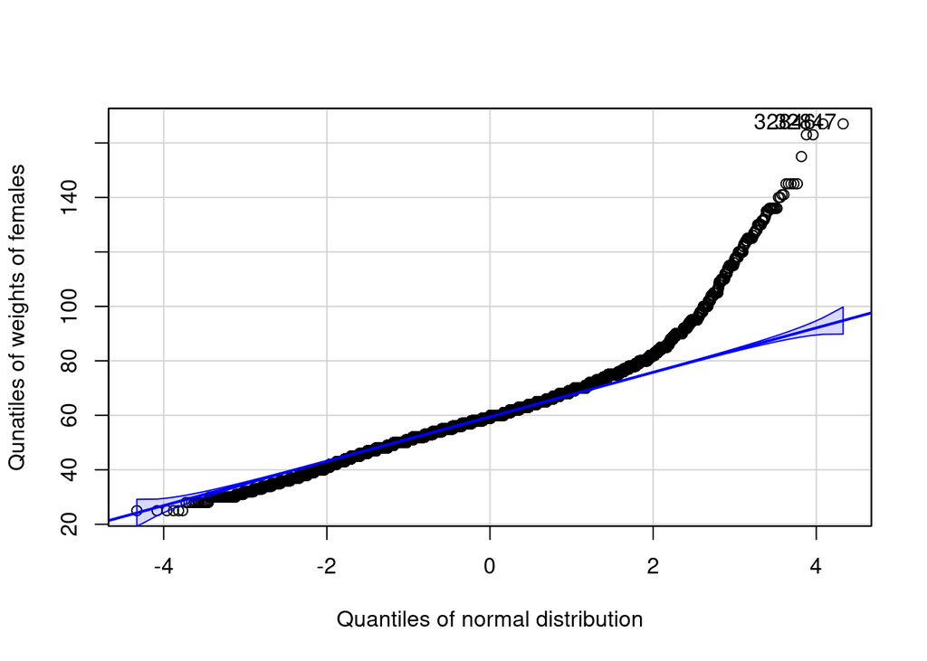

```
## [1] 32846 32847
```

```r
#QQplot
qqPlot(filter(df_ol, Sex == "F")$Weight, xlab = "Quantiles of normal distribution", ylab = "Qunatiles of weights of females")
```

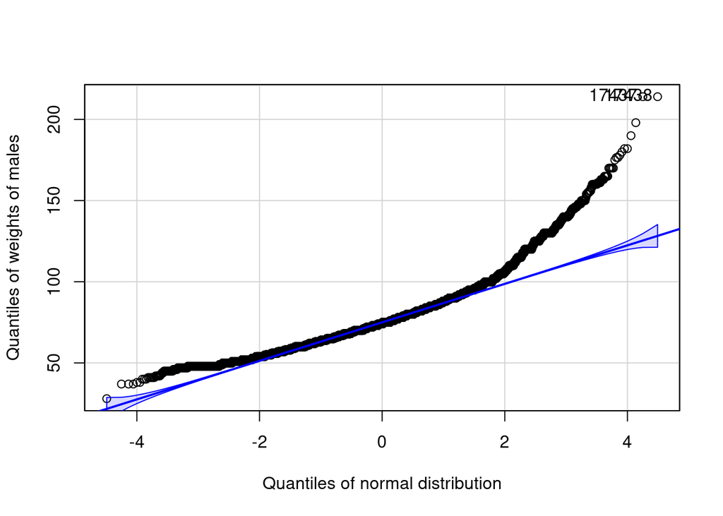

```
## [1] 17437 17438
```

```r
qqPlot(filter(df_ol, Sex == "M")$Weight, xlab = "Quantiles of normal distribution", ylab = "Quantiles of weights of males")
```

```r
#t-test
t_weight <- t.test(filter(df_ol, Sex == "F")$Weight, filter(df_ol, Sex == "M")$Weight, alternative = "two.sided")
t_weight
```

```
##
##  Welch Two Sample t-test
##
## data:  filter(df_ol, Sex == "F")$Weight and filter(df_ol, Sex == "M")$Weight
## t = -297.36, df = 165260, p-value < 2.2e-16
## alternative hypothesis: true difference in means is not equal to 0
## 95 percent confidence interval:
##  -15.82638 -15.61911
## sample estimates:
## mean of x mean of y
##  60.02133  75.74407
```

```r
t_weight <- tidy(t_weight)[c("statistic", "p.value", "parameter", "method", "alternative")]
names(t_weight) <- c("Statistic", "P Value", "Degrees of Freedom", "Method", "Alternative Hypothesis")
t_weight
```

```
## # A tibble: 1 × 5
##   Statistic `P Value` `Degrees of Freedom` Method                  `Alternative Hy…
##       <dbl>     <dbl>                <dbl> <chr>                   <chr>
## 1     -297.         0              165260. Welch Two Sample t-test two.sided
```

Now let’s do the same for height:

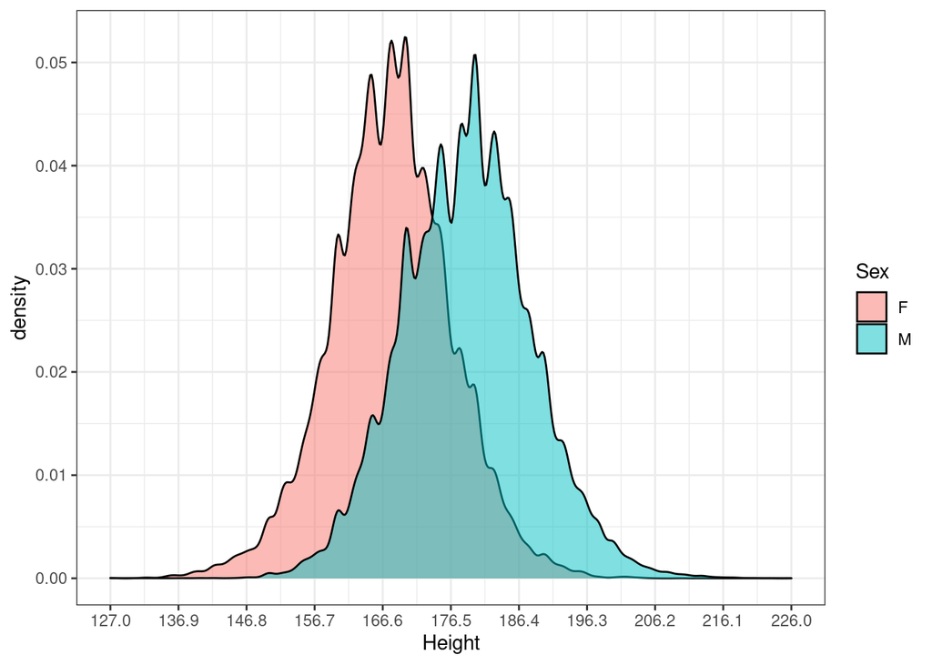

```r
#Testing for normal distribution
ggplot(subset(df_ol, complete.cases(Sex)), aes(Height, fill = Sex))+
  geom_density(alpha = 0.5)+
  scale_x_continuous(name = "Height",
                     limits = c(min(df_ol$Height, na.rm = T), max(df_ol$Height, na.rm = T)),
                     breaks = seq(min(df_ol$Height, na.rm = T), max(df_ol$Height, na.rm = T),
                                  (max(df_ol$Height, na.rm=T)-min(df_ol$Height, na.rm = T))/10)) +
  scale_fill_discrete(name = "Sex")+
  theme_bw()
```

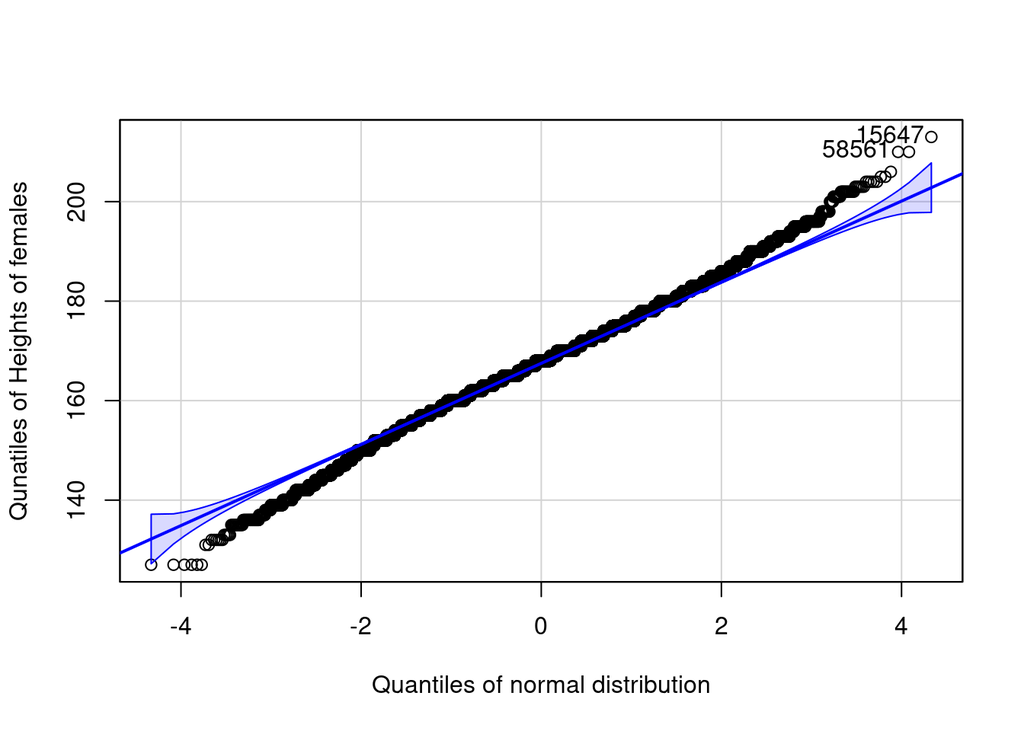

```
## [1] 15647 58561
```

```r
#QQplot
qqPlot(filter(df_ol, Sex == "F")$Height, xlab = "Quantiles of normal distribution", ylab = "Qunatiles of Heights of females")
```

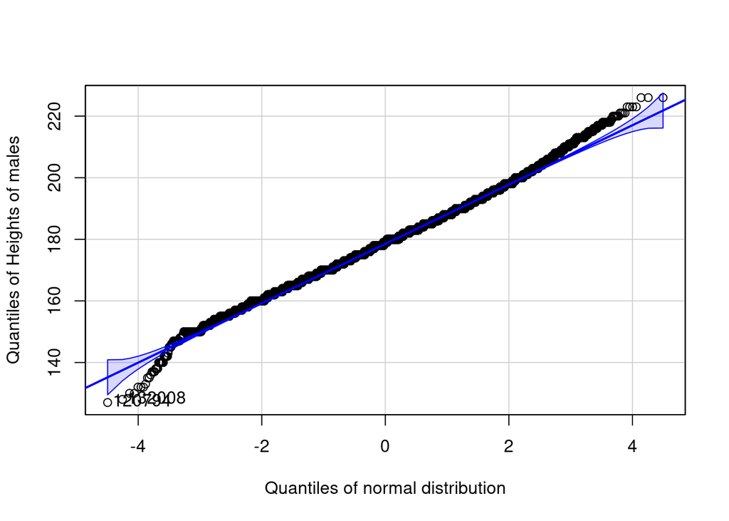

```
## [1] 120794 132008
```

```r
qqPlot(filter(df_ol, Sex == "M")$Height, xlab = "Quantiles of normal distribution", ylab = "Quantiles of Heights of males")
```

```r
#Everything is normally distributed.

#t-test
t_height <- t.test(filter(df_ol, Sex == "F")$Height, filter(df_ol, Sex == "M")$Height, alternative = "two.sided")
t_height
```

```
##
##  Welch Two Sample t-test
##
## data:  filter(df_ol, Sex == "F")$Height and filter(df_ol, Sex == "M")$Height
## t = -263.1, df = 139790, p-value < 2.2e-16
## alternative hypothesis: true difference in means is not equal to 0
## 95 percent confidence interval:
##  -11.10098 -10.93681
## sample estimates:
## mean of x mean of y
##  167.8397  178.8586
```

```r
t_height <- tidy(t_height)[c("statistic", "p.value", "parameter", "method", "alternative")]
names(t_height) <- c("Statistic", "P Value", "Degrees of Freedom", "Method", "Alternative Hypothesis")
t_height
```

```
## # A tibble: 1 × 5
##   Statistic `P Value` `Degrees of Freedom` Method                  `Alternative Hy…
##       <dbl>     <dbl>                <dbl> <chr>                   <chr>
## 1     -263.         0              139790. Welch Two Sample t-test two.sided
```

Description as in article: The height distribution of females and males participating in Olympic games were compared. As the height was normally distributed, two-sided Welch Two Sample t-test was used and significant difference was discovered, with test statistic equal to -263.101237 and p-Value of 0.